# Template Cox proportional hazards model

João Vítor Souza

Packages required

```r
# Essential packages
library(survival); library(survminer); library(Greg)
# Useful packages
library(gtsummary); library(ggplot2); library(dplyr)
```

## Sample data set

The lung dataset is available from the `survival` package in R. The data contain subjects with advanced lung cancer from the North Central Cancer Treatment Group (NCCTG).

Variables of interest:

- time: Survival time in days;
- status: censoring status 1=censored, 2=dead;
- sex: Male=1 Female=2;

```r
head(lung)
```

|  | inst | time | status | age | sex | ph.ecog | ph.karno | pat.karno | meal.cal | wt.loss |
| --- | --- | --- | --- | --- | --- | --- | --- | --- | --- | --- |
| 1 | 3 | 306 | 2 | 74 | 1 | 1 | 90 | 100 | 1175 | NA |
| 2 | 3 | 455 | 2 | 68 | 1 | 0 | 90 | 90 | 1225 | 15 |
| 3 | 3 | 1010 | 1 | 56 | 1 | 0 | 90 | 90 | NA | 15 |
| 4 | 5 | 210 | 2 | 57 | 1 | 1 | 90 | 60 | 1150 | 11 |
| 5 | 1 | 883 | 2 | 60 | 1 | 0 | 100 | 90 | NA | 0 |
| 6 | 12 | 1022 | 1 | 74 | 1 | 1 | 50 | 80 | 513 | 0 |

## Check the distribution of time of survival

Here we will also check for the differences between patients that were censored or not

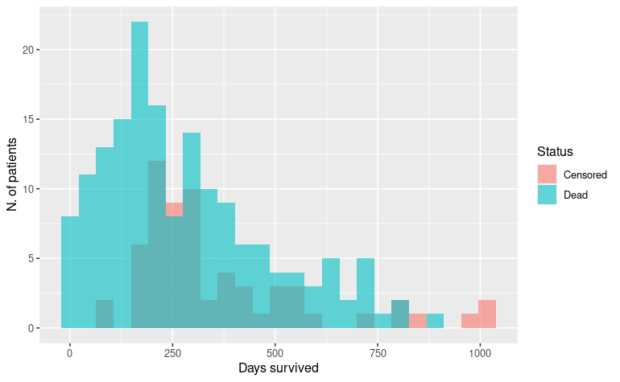

## What if you need to calculate the time?

It is common for us to only have dates that events occurred. In this sense, we can work with the date/time format to get the difference of time between these events.

Examples: * Date and time of death - Date and time of beginning of treatment; * Date and time of discharge - Date and time of admission;

### Example 1: Dates

Here I will create a small example of dates of arrival (`date_arred`) and discharge (`dc_date`) from hospital.

```r
date_ex <-
  tibble(date_arred = c("2007-02-20", "2004-08-13", "2010-10-27"),
         dc_date = c("2007-04-15", "2004-08-18", "2010-10-28"))
date_ex
```

| date_arred | dc_date |
| --- | --- |
| 2007-02-20 | 2007-04-15 |
| 2004-08-13 | 2004-08-18 |
| 2010-10-27 | 2010-10-28 |

We can transform dates into `POSIXct` format with the as.POSIXct function.

Here we can specify the format (e.g. YYYY-mm-dd) of the date/time variables as well as the separators used.

[List of available formats - bottom of the page](https://stat.ethz.ch/R-manual/R-devel/library/base/html/strptime.html)

```r
# Transforming variables to date/time format
arrival <- as.POSIXct(date_ex$date_arred, format="%Y-%m-%d")
discharge <- as.POSIXct(date_ex$dc_date, format="%Y-%m-%d")

# Calculating the difference of time between arrival and discharge
date_ex$delta_arr_dc <- as.numeric(difftime(discharge, arrival, units = "days"))

date_ex
```

| date_arred | dc_date | delta_arr_dc |
| --- | --- | --- |
| 2007-02-20 | 2007-04-15 | 54.04167 |
| 2004-08-13 | 2004-08-18 | 5.00000 |
| 2010-10-27 | 2010-10-28 | 1.00000 |

### Example 2: Dates and times

Now, let’s assume you have both date and time of arrival and discharge and want to consider time as well.

```r
date_ex2 <-
  tibble(date_arred = c("2007-02-20", "2004-08-13", "2010-10-27"),
         time_arred = c("20:20", "18:00", "12:15"),
         dc_date = c("2007-04-15", "2004-08-18", "2010-10-28"),
         dc_time = c("19:11", "10:10", "09:00"))
date_ex2
```

| date_arred | time_arred | dc_date | dc_time |
| --- | --- | --- | --- |
| 2007-02-20 | 20:20 | 2007-04-15 | 19:11 |
| 2004-08-13 | 18:00 | 2004-08-18 | 10:10 |
| 2010-10-27 | 12:15 | 2010-10-28 | 09:00 |

Now we need to: 1. Paste date and time together; 2. Transform it to POSIXct considering the new format; 3. Calculate the differences;

```r
# Here I paste the date and time of arrival into a single thing
arrival_date_time <- paste(date_ex2$date_arred, date_ex2$time_arred, sep="-")
arrival_date_time
```

```
[1] "2007-02-20-20:20" "2004-08-13-18:00" "2010-10-27-12:15"
```

```r
# Now I transform it to date/time, considering the format needed
arrival_date_time <- as.POSIXct(arrival_date_time,
                                format="%Y-%m-%d-%H:%M")
# Now we do the same for discharge
discharge_date_time <- paste(date_ex2$dc_date, date_ex2$dc_time, sep="-")
discharge_date_time
```

```
[1] "2007-04-15-19:11" "2004-08-18-10:10" "2010-10-28-09:00"
```

```r
discharge_date_time <- as.POSIXct(discharge_date_time,
                                format="%Y-%m-%d-%H:%M")

# Calculating the difference of time between arrival and discharge
date_ex2$delta_arr_dc <- as.numeric(difftime(discharge_date_time,
                                            arrival_date_time,
                                            units = "days"))
# Now we have the amount of days between arrival and discharge, considering the time as well
date_ex2
```

| date_arred | time_arred | dc_date | dc_time | delta_arr_dc |
| --- | --- | --- | --- | --- |
| 2007-02-20 | 20:20 | 2007-04-15 | 19:11 | 53.9937500 |
| 2004-08-13 | 18:00 | 2004-08-18 | 10:10 | 4.6736111 |
| 2010-10-27 | 12:15 | 2010-10-28 | 09:00 | 0.8645833 |

## Kaplan-Meier method

```r
f1 <- survfit(Surv(time, status) ~ 1, data = lung)
f1
```

```
Call: survfit(formula = Surv(time, status) ~ 1, data = lung)

       n events median 0.95LCL 0.95UCL
[1,] 228    165    310     285     363
```

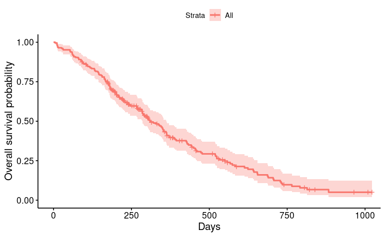

```r
surv.f1 <- ggsurvplot(
  fit = f1,
  xlab = "Days",
  ylab = "Overall survival probability")

plot.new()
print(surv.f1,newpage = FALSE)
```

## Comparing survival times between groups

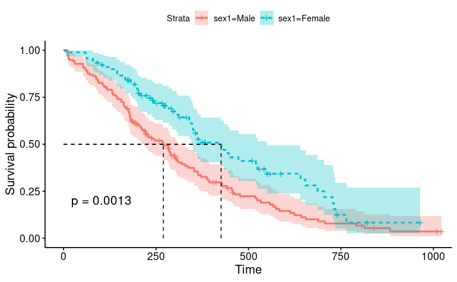

```r
lung$sex1 <- factor(lung$sex, levels=c(1,2), labels=c("Male", "Female"))

# specify event 1=event at time, 2=left censored, 3=interval censored
fit <- survfit(Surv(time, status) ~ sex1 , data = lung)

surv.sex <- ggsurvplot(fit=fit, data = lung,
                       linetype="strata", surv.median.line = "hv",
                       conf.int = TRUE, pval=TRUE)

plot.new()
print(surv.sex,newpage = FALSE)
```

### Cox proportional hazards model

```r
res.cox <- coxph(Surv(time, status) ~ sex1 , data = lung)
summary(res.cox)
```

```
Call:
coxph(formula = Surv(time, status) ~ sex1, data = lung)

  n= 228, number of events= 165

              coef exp(coef) se(coef)      z Pr(>|z|)
sex1Female -0.5310    0.5880   0.1672 -3.176  0.00149 **
---
Signif. codes:  0 ‘***’ 0.001 ‘**’ 0.01 ‘*’ 0.05 ‘.’ 0.1 ‘ ’ 1

           exp(coef) exp(-coef) lower .95 upper .95
sex1Female     0.588      1.701    0.4237     0.816

Concordance= 0.579  (se = 0.021 )
Likelihood ratio test= 10.63  on 1 df,   p=0.001
Wald test            = 10.09  on 1 df,   p=0.001
Score (logrank) test = 10.33  on 1 df,   p=0.001
```

The above shows the raw output of the model. Here we can point out:

- **exp(coef)**, which translates into the Hazard Risk observed.

For this example, we have the HR of having the event being Female, compared to being Male. The above data shows that the class Female has ~40% reduction in the HR of the event (death). To simply put it, a HR >1 indicates increased risk and a HR <1 indicates reduced risk.

- **se(coef)**, which is the standard error of the HR. It is used to calculate the confidence interval of the model;
- **lower .95 upper .95**. The lower and upper boundaries of the confidence interval of the HR;
- **Pr(>|z|)**, the result of statistical testing that determines whether the HR found is significant at a certain degree or not;
- Likelihood ratio test, Wald test and Score (logrank) test are tests that evaluate if the model is significantlly different from the null model. The one most recommend for Cox regression is the likelihood ratio test.

Now we can generate a nice table using `gtsummary`

```r
res.cox %>% tbl_regression(exp = TRUE) %>% bold_p()
```

| **Characteristic** | **HR**<sup>1</sup> | **95% CI**<sup>1</sup> | **p-value** |
| --- | --- | --- | --- |
| sex1 |  |  |  |
| Male | — | — |  |
| Female | 0.59 | 0.42, 0.82 | 0.001 |

<sup>1</sup> HR = Hazard Ratio, CI = Confidence Interval

### Testing multiple variables at once

```r
# Changing variable to factor
lung$ph.ecog1 <- factor(lung$ph.ecog)
# Include the variables you want to test with the time to event
covariates <-  c( "age","sex1", "wt.loss", "ph.ecog1")
# Use this list to include nice labels for the final table
var_names <- list(age~"Age",
                  sex1~"Sex",
                  wt.loss~"Weight Loss",
                  ph.ecog1~"PH Ecog")

tbl_univ <-
  tbl_uvregression(
    lung[,c(covariates, "time", "status")],
    label=var_names,
    method = coxph,
    y = Surv(time, status),
    exponentiate = TRUE) %>%
  bold_p() %>% bold_labels()
tbl_univ
```

| **Characteristic** | **N** | **HR**<sup>1</sup> | **95% CI**<sup>1</sup> | **p-value** |
| --- | --- | --- | --- | --- |
| Age | 228 | 1.02 | 1.00, 1.04 | 0.042 |
| Sex | 228 |  |  |  |
| Male |  | — | — |  |
| Female |  | 0.59 | 0.42, 0.82 | 0.001 |
| Weight Loss | 214 | 1.00 | 0.99, 1.01 | 0.8 |
| PH Ecog | 227 |  |  |  |
| 0 |  | — | — |  |
| 1 |  | 1.45 | 0.98, 2.13 | 0.063 |
| 2 |  | 2.50 | 1.61, 3.88 | <0.001 |
| 3 |  | 9.10 | 1.22, 67.9 | 0.031 |

<sup>1</sup> HR = Hazard Ratio, CI = Confidence Interval

### Multi-variate Cox proportonional hazards model

```r
res.cox.multiv <- coxph(Surv(time, status) ~  age + sex1 + wt.loss +
                        ph.ecog1, data = lung)
summary(res.cox.multiv)
```

```
Call:
coxph(formula = Surv(time, status) ~ age + sex1 + wt.loss + ph.ecog1,
    data = lung)

  n= 213, number of events= 151
   (15 observations deleted due to missingness)

                coef exp(coef)  se(coef)      z Pr(>|z|)
age         0.013104  1.013191  0.009674  1.355 0.175535
sex1Female -0.582551  0.558472  0.175940 -3.311 0.000929 ***
wt.loss    -0.009093  0.990948  0.006703 -1.357 0.174934
ph.ecog11   0.459666  1.583545  0.208270  2.207 0.027310 *
ph.ecog12   1.004668  2.731000  0.252838  3.974 7.08e-05 ***
ph.ecog13   2.161748  8.686305  1.038190  2.082 0.037322 *
---
Signif. codes:  0 ‘***’ 0.001 ‘**’ 0.01 ‘*’ 0.05 ‘.’ 0.1 ‘ ’ 1

           exp(coef) exp(-coef) lower .95 upper .95
age           1.0132     0.9870    0.9942    1.0326
sex1Female    0.5585     1.7906    0.3956    0.7884
wt.loss       0.9909     1.0091    0.9780    1.0041
ph.ecog11     1.5835     0.6315    1.0528    2.3818
ph.ecog12     2.7310     0.3662    1.6638    4.4827
ph.ecog13     8.6863     0.1151    1.1353   66.4575

Concordance= 0.647  (se = 0.026 )
Likelihood ratio test= 31.43  on 6 df,   p=2e-05
Wald test            = 31.56  on 6 df,   p=2e-05
Score (logrank) test = 33.97  on 6 df,   p=7e-06
```

The summary of the multivariate model follows the same format explained before

Generating a nice table of results

```r
var_names <- list(age~"Age",
                  sex1~"Sex",
                  wt.loss~"Weight Loss",
                  ph.ecog1~"PH Ecog")
tbl_multiv <- res.cox.multiv %>%
  tbl_regression(label=var_names, exponentiate=TRUE) %>% bold_p() %>% bold_labels
tbl_multiv
```

| **Characteristic** | **HR**<sup>1</sup> | **95% CI**<sup>1</sup> | **p-value** |
| --- | --- | --- | --- |
| Age | 1.01 | 0.99, 1.03 | 0.2 |
| Sex |  |  |  |
| Male | — | — |  |
| Female | 0.56 | 0.40, 0.79 | <0.001 |
| Weight Loss | 0.99 | 0.98, 1.00 | 0.2 |
| PH Ecog |  |  |  |
| 0 | — | — |  |
| 1 | 1.58 | 1.05, 2.38 | 0.027 |
| 2 | 2.73 | 1.66, 4.48 | <0.001 |
| 3 | 8.69 | 1.14, 66.5 | 0.037 |

<sup>1</sup> HR = Hazard Ratio, CI = Confidence Interval

```r
NA
```

For the table above, we can interpret that: * *Age* does not seem to have an important influence on the survival rates; * *Females* have ~40% (HR=0.56) less risk of having the event than males (p<0.001). The CI ranges from 60% (HR=0.40) to 21% (HR=0.79) less risk; * *Weight Loss* does not seem to be significant; * Having *Ph Ecog* of 1, 2 or 3 implies on significant higher risk of event compared to the reference, HR=1.58, HR=2.73 and HR=8.69, respectively.

Combining tables

```r
tbl_merge(tbls=list(tbl_univ, tbl_multiv),
          tab_spanner=c("Univariate", "Multivariate"))
```

[output not shown]

## Checking model assumptions

After we have built our model it is necessary to check whether it is biased or violates assumptions.

The tests we need to perform are: * Proportional hazards assumption; * Examining influential observations (or outliers). * Detecting non linearity in relationship between the log hazard and the covariates.

In order to check for these, *Residuals* method are used. Common residuals for cox include:

- Schoenfeld residuals to check the proportional hazards assumption;
- Martingale residual to assess non linearity;
- Deviance residual (symmetric transformation of the Martinguale residuals), to examine influential observations;

[Complete guide - Sthda](http://www.sthda.com/english/wiki/cox-model-assumptions)

```r
res.cox.multiv
```

[output not shown]

### Proportional hazard assumption

```r
test.ph <- cox.zph(res.cox.multiv)
test.ph
```

[output not shown]

```r
plot.ph <- ggcoxzph(test.ph)

plot.new()
print(plot.ph,newpage = FALSE)
```

[output not shown]

Violations of proportional hazards assumption can be resolved by:

- Adding covariate * time interaction
- Stratification

```r
lung.update <- lung %>%
  mutate(status= factor(status,
                        levels=1:2,
                        labels=c("Censored","Died")),
         time=time/365.25,
         sex=factor(sex,
                    levels=1:2,
                    labels=c("Male","Female")),
         ph.ecog=factor(ph.ecog)
         )
```

```r
library(Greg)
regular.model <- coxph(Surv(time, status=="Died") ~ sex + age + wt.loss + ph.ecog, data = lung.update)

summary(regular.model)
```

[output not shown]

```r
split_lung <- lung.update %>% timeSplitter(by=.5,
                                    event_var ="status",
                                    time_var="time",
                                    time_related_vars = "age")

interval.model <-
  update(regular.model,
         Surv(Start_time, Stop_time, status == "Died") ~ .,
         data = split_lung)

summary(interval.model)
```

[output not shown]

[output cut: 487 more lines]

```r
library(htmlTable)
cbind(Regular = coef(regular.model),
      Interval = coef(interval.model),
      Difference = coef(regular.model) - coef(interval.model)) %>%
  txtRound(digits = 5) %>%
  knitr::kable(align = "r")
```

[output not shown]

```r
cox.zph(regular.model)
```

[output not shown]

```r
time.int.model <- update(interval.model,
                         .~.+sex:Start_time)
summary(time.int.model)
```

[output not shown]

```r
split_lung$sex_start = (split_lung$sex=="Male")*split_lung$Start_time

anova(time.int.model,
      update(time.int.model, .~.+I(sex_start^2)))

split_lung
```

[output not shown]

### Examining influential observations

```r
ggcoxdiagnostics(res.cox.multiv, type='dfbeta', linear.predictions = TRUE)
```

[output not shown]

```r
ggcoxdiagnostics(res.cox.multiv, type = "deviance",
                 linear.predictions = FALSE, ggtheme = theme_bw())
```

[output not shown]

### Testing non-linearity

Necessary only for continuous covariates.

Martingale residuals may present any value in the range (-INF, +1):

- Residuals near 1 represents individuals that “died too soon”,
- and large negative values correspond to individuals that “lived too long”.

```r
age.lin_plot <- ggcoxfunctional(Surv(time, status) ~ age + log(age) + sqrt(age), data = lung)
plot.new()
print(age.lin_plot,newpage = FALSE)
```

[output not shown]